# Tarea 1 - Semestre Primavera 2021

## Pregunta 2

```r
reg_p2 <- lm(num_orders ~ center_id + meal_id + base_price + checkout_price + emailer_for_promotion + homepage_featured, df)

#Ids a omitir en la tabla
ids <- unique(df$center_id)
centers_id <- paste('center_id',ids,sep='')
ids_meals <- unique(df$meal_id)
meals_id <- paste('meal_id',ids_meals,sep='')


stargazer(reg_p2, type='html',omit.stat = c("F","ser","adj.rsq"), no.space = FALSE, omit=c(centers_id, meals_id), out='p2.htm')
```

|  | *Dependent variable:* |
| --- | --- |
|  | num_orders |
| base_price | 0.161*** |
|  | (0.015) |
| checkout_price | -0.711*** |
|  | (0.012) |
| emailer_for_promotion1 | 267.852*** |
|  | (1.968) |
| homepage_featured1 | 222.989*** |
|  | (1.553) |
| Constant | 759.294*** |
|  | (5.043) |
| Observations | 456,548 |
| R<sup>2</sup> | 0.484 |
| *Note:* | p<0.1; p<0.05; p<0.01 |

## Pregunta 3

Creamos la variable `EsAsiatico` que vale 1 si la cocina es asiática, vale decir, es “Thai” o “Indian”. De esta forma, vamos a correr dos regresiones, una que contiene la interacción entre esta nueva variable y `emailer_promotion` y otra que contiene la regresión(sin considerar esta nueva variable) entre `cuisine` y `emailer_for_promotion`.

La idea es observar cómo se comporta la regresión en base a definir esta nueva variable `EsAsiatico` y compararla respecto a considerar las 4 categorias de `cuisine` e interactuarla con `emailer_for_promotion`.

Además, para estas regresiones se testearán 4 modelos, 2 incluyendo meal_id y otros sin incluirlo, por posible problemas de multiconlinealidad.

```r
df$EsAsiatico <- ifelse(df$cuisine=='Thai' | df$cuisine=='Indian',1,0)

reg_p31 <- lm(num_orders ~  meal_id + center_id  + checkout_price + base_price + homepage_featured + EsAsiatico*emailer_for_promotion, df)
reg_p32 <- lm(num_orders ~  meal_id +center_id + checkout_price  + base_price + homepage_featured + cuisine*emailer_for_promotion, df)
reg_p33 <- lm(num_orders ~  center_id + checkout_price  + base_price + homepage_featured + EsAsiatico*emailer_for_promotion, df)
reg_p34 <- lm(num_orders ~  center_id  + checkout_price + base_price + homepage_featured + cuisine*emailer_for_promotion, df)

ids <- unique(df$center_id)
centers_id <- paste('center_id',ids,sep='')

stargazer(reg_p31, reg_p32, reg_p33,reg_p34, header=FALSE, type='html',omit.stat = c("F","ser","adj.rsq"), no.space = FALSE, omit=c(centers_id, meals_id), out='p3.htm')
```

|  | *Dependent variable:* |  |  |  |
| --- | --- | --- | --- | --- |
|  | num_orders |  |  |  |
|  | (1) | (2) | (3) | (4) |
| checkout_price | -0.783*** | -1.074*** | -0.471*** | -0.637*** |
|  | (0.012) | (0.012) | (0.013) | (0.013) |
| base_price | 0.198*** | 0.378*** | -0.355*** | -0.190*** |
|  | (0.015) | (0.015) | (0.013) | (0.013) |
| homepage_featured1 | 222.777*** | 218.545*** | 255.151*** | 262.048*** |
|  | (1.548) | (1.514) | (1.786) | (1.762) |
| EsAsiatico |  |  | -114.223*** |  |
|  |  |  | (1.121) |  |
| cuisineIndian |  |  |  | -89.642*** |
|  |  |  |  | (1.746) |
| cuisineItalian |  |  |  | -6.097*** |
|  |  |  |  | (1.891) |
| cuisineThai |  |  |  | -144.579*** |
|  |  |  |  | (2.132) |
| emailer_for_promotion1 | 208.170*** | -14.912*** | 243.414*** | 73.884*** |
|  | (2.262) | (2.897) | (2.611) | (3.329) |
| EsAsiatico:emailer_for_promotion1 | 189.702*** |  | 245.896*** |  |
|  | (3.578) |  | (4.173) |  |
| cuisineIndian:emailer_for_promotion1 |  | 554.422*** |  | 563.014*** |
|  |  | (4.414) |  | (5.163) |
| cuisineItalian:emailer_for_promotion1 |  | 469.895*** |  | 383.429*** |
|  |  | (3.847) |  | (4.481) |
| cuisineThai:emailer_for_promotion1 |  | 90.703*** |  | 47.840*** |
|  |  | (5.678) |  | (6.701) |
| Constant | 768.076*** | 776.837*** | 780.133*** | 782.717*** |
|  | (5.030) | (4.920) | (4.311) | (4.838) |
| Observations | 456,548 | 456,548 | 456,548 | 456,548 |
| R<sup>2</sup> | 0.487 | 0.509 | 0.277 | 0.302 |
| *Note:* | p<0.1; p<0.05; p<0.01 |  |  |  |

Podemos observar en el `modelo (3)` que si la cocina es asiática tiene un efecto significativo y negativo de 114 unidades menos en la cantidad de órdenes, sin embargo, al ver el efecto de la promoción, y si es asiatico el efecto es bastante positivos, nos dice que si el plato es asiático y se enviar promociones por correo el efecto que se tiene es un aumento significativo de 245 sobre el nivel de órdenes. Cabe destacar, que este efecto cuando ocurren ambos hechos a la vez es un poco menor, lo cual es contradictorio, ya que el ser asiatico debería disminuir la cantidad de ordenes y contrarrestar a la promoción por mail. Sin embargo, puede deberse a un problema de endogeneidad.

Con respecto al `modelo (4)`` y agregamos el efecto por el tipo de cocina, se puede observar que la interacción entre comida India y enviar un correo de promoción aumenta la cantidad de órdenes enormemente, en 563 unidades respecto a la continental, la cual queda como base de comparación. Lo mismo con la cocina italiana, que se ve aumentada en 383 órdenes respecto a la cocina continental. Lo mismo ocurre con la cocina Thai aumenta en 47 unidades la cantidad de órdenes respecto a la comida continental, con una significancia al 1% o mayor.

Dicho lo anterior, se puede decir que los platos asiáticos si responden a las promociones, sobre todo aquellos que son de cocina India.

Los modelos (1) y (2) son análogos al (3) y (4), sólo que incluyen la variable meal_id, por lo que algunos coeficientes no se calculan por multicolinealidad. Sin embargo, aportan las mismas conclusiones.

Finalmente, se trabajará con el modelo (2), que considera la interacción de `cuisine` con `email_for_promotion` y además `mail_id`. Ya que, interpreta bastante mejor la variabilidad de los datos a diferencia del modelo (4), pues posee el mayor $R^2$.

## Pregunta 4

```r
reg_p41 <- lm(num_orders ~  meal_id + checkout_price + base_price + emailer_for_promotion*cuisine + homepage_featured  + center_id, df)
reg_p42 <- lm(num_orders ~  meal_id + checkout_price + base_price + emailer_for_promotion*cuisine + homepage_featured  + city_code + center_type + op_area, df)
reg_p43 <- lm(num_orders ~  meal_id + checkout_price + base_price + emailer_for_promotion*cuisine + homepage_featured  + center_type + op_area, df)
reg_p44 <- lm(num_orders ~  meal_id + checkout_price + base_price + emailer_for_promotion*cuisine + homepage_featured + center_type + op_area, df)
reg_p45 <- lm(num_orders ~  meal_id + checkout_price + base_price + emailer_for_promotion*cuisine + homepage_featured  + op_area, df)


ids_cities <- unique(df$city_code)
city_codes <- paste('city_code',ids_cities,sep='')


stargazer(reg_p41, reg_p42,reg_p43,reg_p44,reg_p45, header=FALSE, type='html', omit.stat = c("F","ser","adj.rsq"), omit=c(centers_id,city_codes,meals_id), out='p4.htm')
```

|  | *Dependent variable:* |  |  |  |  |
| --- | --- | --- | --- | --- | --- |
|  | num_orders |  |  |  |  |
|  | (1) | (2) | (3) | (4) | (5) |
| checkout_price | -1.074*** | -1.073*** | -1.018*** | -1.018*** | -1.015*** |
|  | (0.012) | (0.012) | (0.012) | (0.012) | (0.012) |
| base_price | 0.378*** | 0.359*** | 0.610*** | 0.610*** | 0.603*** |
|  | (0.015) | (0.015) | (0.015) | (0.015) | (0.015) |
| emailer_for_promotion1 | -14.912*** | -15.945*** | -13.769*** | -13.769*** | -13.620*** |
|  | (2.897) | (2.930) | (3.011) | (3.011) | (3.012) |
| cuisineIndian |  |  |  |  |  |
| cuisineItalian |  |  |  |  |  |
| cuisineThai |  |  |  |  |  |
| homepage_featured1 | 218.545*** | 219.978*** | 225.761*** | 225.761*** | 225.996*** |
|  | (1.514) | (1.530) | (1.567) | (1.567) | (1.567) |
| center_typeTYPE_B |  | 47.124*** | 13.665*** | 13.665*** |  |
|  |  | (1.895) | (1.144) | (1.144) |  |
| center_typeTYPE_C |  | -22.225*** | -15.881*** | -15.881*** |  |
|  |  | (1.951) | (1.139) | (1.139) |  |
| op_area |  | 73.158*** | 70.610*** | 70.610*** | 74.763*** |
|  |  | (0.808) | (0.446) | (0.446) | (0.395) |
| emailer_for_promotion1:cuisineIndian | 554.422*** | 554.776*** | 545.052*** | 545.052*** | 545.299*** |
|  | (4.414) | (4.464) | (4.588) | (4.588) | (4.589) |
| emailer_for_promotion1:cuisineItalian | 469.895*** | 470.034*** | 462.974*** | 462.974*** | 462.975*** |
|  | (3.847) | (3.890) | (3.998) | (3.998) | (3.999) |
| emailer_for_promotion1:cuisineThai | 90.703*** | 91.211*** | 74.923*** | 74.923*** | 75.052*** |
|  | (5.678) | (5.742) | (5.900) | (5.900) | (5.902) |
| Constant | 776.837*** | 260.143*** | 185.183*** | 185.183*** | 168.152*** |
|  | (4.920) | (6.084) | (4.108) | (4.108) | (4.003) |
| Observations | 456,548 | 456,548 | 456,548 | 456,548 | 456,548 |
| R<sup>2</sup> | 0.509 | 0.498 | 0.470 | 0.470 | 0.469 |
| *Note:* | p<0.1; p<0.05; p<0.01 |  |  |  |  |

Podemos notar desde ya que la variable `center_id` se correlaciona unívocamente con las variables `city_code`, `region_code`, `center_type`, `op_area`, pues, todos estos atributos definen unicamente a `center_id`.

Se plantearán 5 regresiones combinando los diferentes atributos de `fullfilment_center` para ver cuál evidencia mejores resultados. Asi, finalmente se compararán respecto a sólo agregar `center_id`.

*Nota: No se mostraron los coeficientes de `meal_id` ya que no se consideraron relevantes para el análisis. Todas las regresiones los consideran*

## Pregunta 5

Para realizar esto, realizaremos un rezago de 4 periodos sobre la variable `num_orders` y de esta manera agregaremos una nueva columna al `dataframe` llamada `lag4num_orders`, asi correremos una regresión donde incluiremos esta variable, para ver el efecto que tiene este rezago de 4 semanas sobre la variable dependiente del número de órdenes.

```r
library(dplyr)
library(Hmisc)
#Creamos el rezago
df_p6 <- df %>% arrange(center_id, meal_id, week) %>% group_by(center_id, meal_id) %>% mutate(lag4num_orders=Lag(num_orders, shift = 4)) %>% select(lag4num_orders)
#Agregamos la columna al dataframe
df$lag4num_orders <- df_p6$lag4num_orders
```

```r
reg_p5 <- lm(num_orders ~  meal_id +center_id + checkout_price  + base_price + homepage_featured + cuisine*emailer_for_promotion + lag4num_orders, df)

#Ignorar en el print
ids_weeks <- unique(df$week)
weeks_id <- paste('week',ids_weeks,sep='')

stargazer(reg_p5, header=FALSE, type='html', omit.stat = c("F","ser","adj.rsq"), omit=c(centers_id,city_codes,meals_id,weeks_id), out='p5.htm')
```

[output not shown]

Podemos notar que el efecto de la variable con retardo de 4 semanas es de 0.003, significativa al 5%. El efecto es muy pequeño, que incluso lo podríamos considerar despreciable. Esto se podría interpretar como que las ordenes de hoy no tendrán mucho impacto en las de 4 semanas posteriores. El efecto es significativo, pero no se puede predecir directamente.

## Pregunta 6

Para este caso, consideraremos los mejores modelos de las preguntas anteriores en base a los analisis realizados y los testearemos respecto a su nivel de predicción. Analiticamente se pueden observar en la siguiente tabla. Cabe destacar que las variables con muchos coeficientes fueron omitidos en los resultados para que sean más legibles las variables más interpretables.

```r
stargazer(reg_p2,reg_p32,reg_p41,reg_p5, header=FALSE, type='html', omit.stat = c("F","ser","adj.rsq"), omit=c(centers_id,city_codes,meals_id,weeks_id), out='p6.htm')
```

[output not shown]

### Dividimos los datos en train y test.

```r
set.seed(24) #Seteamos la semilla para obtener resultados replicables
# Construimos un vector que esta formado por números de filas aleatoriamente
index <- sample(1:nrow(df), size= nrow(df)*0.7)
# Base de entrenamiento: del total de datos, tomamos las filas aletorizadas que tienen datos en index
train <- df[index, ]
# Para testing escogemos el complemento de filas
test  <- df[-index, ]
```

### Entrenamos

Realizamos el entrenamiento de los 3 modelos de regresion de las preguntas anteriores y los evaluamos en el conjunto de testing. Todo esto, para tener una idea de cual predice mejor el número de ordenes y que sirve más adelante como punto de contraste.

Nota: El modelo 4 no funcionó con la función train(). Se decidió omitir para el análisis de predicción.

Se utilizará la función readRDS para cargar los modelos.

```r
#train.lm1 <- train(form = num_orders ~ center_id + meal_id + base_price + checkout_price + emailer_for_promotion + homepage_featured,
#  data = train, #Datos
#  method = "lm"
#)

#test.lm1  <- predict(train.lm1 , newdata=test)

#error.lm1 <- test$num_orders-test.lm1
error.lm1 <- readRDS("error_lm1.rds")

#train.lm2 <- train(form = num_orders ~  meal_id +center_id + checkout_price  + base_price + homepage_featured + cuisine*emailer_for_promotion,
#  data = train,
#  method = "lm"
#)

#test.lm2  <- predict(train.lm2 , newdata=test)
#error.lm2 <- test$num_orders-test.lm2
error.lm2 <- readRDS("error_lm2.rds")

#train.lm3 <- train(form = num_orders ~  meal_id + checkout_price + base_price + emailer_for_promotion*cuisine + homepage_featured  + center_id,
#  data = train,
#  method = "lm"
#)

#test.lm3  <- predict(train.lm3 , newdata=test)
#error.lm3 <- test$num_orders-test.lm3
error.lm3 <- readRDS("error_lm3.rds")
```

Guardamos los errores en un dataframe.

```r
error.test_lm <- data.frame(lm1=error.lm1,lm2=error.lm2,lm3=error.lm3)
```

Realizamos un boxplot del error de cada regresión.

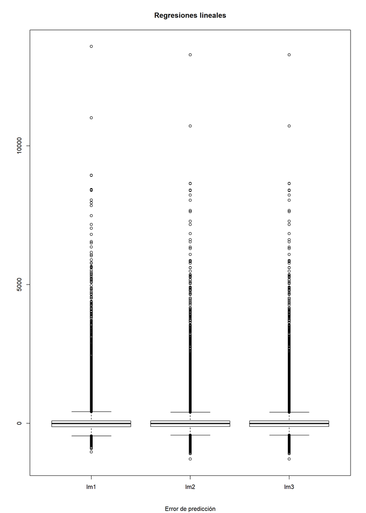

```r
boxplot(error.test_lm ); title(main="Regresiones lineales", sub="Error de predicción")
```

## Pregunta 7

### KNN

Normalizamos los datos y definimos `k=5` para que el modelo considere los 5 vecinos más cercanos. Esto se definió en base a entrenar el modelo previamente y encontrar que es el valor más adeucado.

Luego, utilizaremos la función `readRDS``de R para cargar el modelo entrenado anteriormente(y volver evitar entrenarlo de nuevo)

```r
#train.knn <- train(num_orders ~  meal_id +center_id  + base_price + homepage_featured + cuisine*emailer_for_promotion,
#                   data=train, method="knn",
#                   preProcess = c("center","scale"), #Normalizamos los datos
#                   tuneGrid = expand.grid(k = 5) #Escogemos k=5, es decir, que el mo
#)

train.knn <- readRDS("knn.rds")
print(train.knn)
```

```
## k-Nearest Neighbors
##
## 10000 samples
##     6 predictor
##
## Pre-processing: centered (135), scaled (135)
## Resampling: Bootstrapped (25 reps)
## Summary of sample sizes: 10000, 10000, 10000, 10000, 10000, 10000, ...
## Resampling results:
##
##   RMSE      Rsquared   MAE
##   341.1493  0.3563791  193.9636
##
## Tuning parameter 'k' was held constant at a value of 5
```

```r
#test.knn  <- predict(train.knn, newdata=test)
#error.knn <- test$num_orders-test.knn

test.knn  <- readRDS("test.rds")
error.knn <- readRDS("error.rds")
```

### MARS

Ahora entrenamos con MARS, normalizamos los datos y definimos los hiperparámetros, `degree=1,nprune=2`, en base a entrenar el modelo previamente y encontrar que estos parámetros arrojaban los mejores resultados respecto a la métrica RMSE

```r
#train.mars <- train(num_orders ~  meal_id + center_id  + base_price + homepage_featured + cuisine*emailer_for_promotion,
#                    data=train,
#                    method="earth", #MARS
#                    preProcess = c("center","scale"),
#                    tuneGrid = expand.grid(degree=1, nprune = 2)
#)

#cargamos el modelo que fue entrenado previamente.
#train.mars <- readRDS("mars.rds")
#print(train.mars)
```

Evaluamos MARS en el conjunto de testing, guardamos la predicción y calculamos el error.

```r
#test.mars  <- predict(train.mars, newdata=test)
test.mars <- readRDS('test_mars.rds')
#error.mars <- test$num_orders-test.mars
error.mars <- readRDS("error_mars.rds") #Cargamos los errores previamente calculados para evitar sobrecargarga de memoria
```

### CART

```r
#train.cart <- train(num_orders ~  meal_id +center_id  + base_price + homepage_featured + cuisine*emailer_for_promotion,
#                    data=train[1:100,], method="rpart2",
#                    preProcess = c("center","scale"),
#                    tuneGrid = expand.grid(maxdepth=5)
#)
#train.cart <- readRDS('cart.rds')
#print(train.cart)
```

Evaluamos CART en el conjunto de testing. Para eso cargamos un archivo .rds con los datos calculados previamente y de forma de evitar volver a entrenar el modelo.

```r
#test.cart  <- predict(train.cart, newdata=test)
test.cart <- readRDS('test_cart.rds')
#error.cart <- test$num_orders-test.cart
error.cart <- readRDS('error_cart.rds')
```

### Comparación de modelos

Creamos un `dataframe` con las predicciones y errores de cada modelo.

```r
orders.test <- data.frame(knn=test.knn, mars=unname(test.mars),  cart=test.cart)
error.test <- data.frame(knn=error.knn, mars=unname(error.mars), cart=error.cart)
```

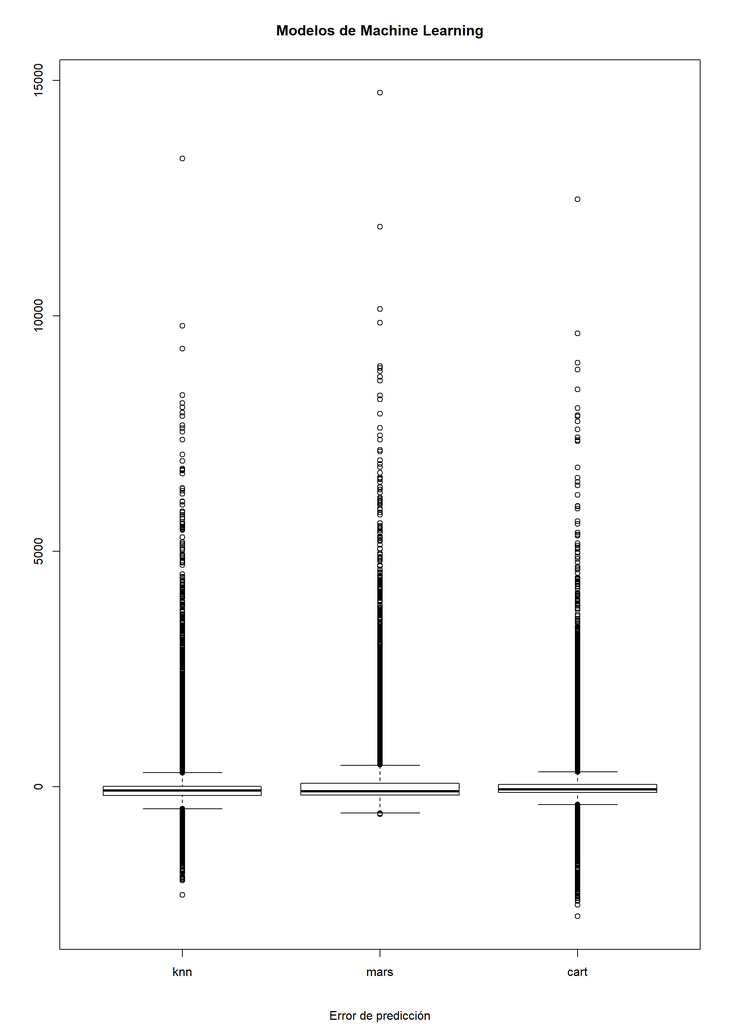

```r
boxplot(error.test); title(main="Modelos de Machine Learning", sub="Error de predicción")
```

La ventaja de utilizar este tipo de modelos es que pueden encontrar relaciones no-lineales en los datos, y de alguna manera encontrar patrones que modelos comúnes no logran explicar. También, en cierto sentido uno no debe realizar mucho procesamiento a los atributos, a parte de la limpieza, ya que se deben entregar directamente las variables que se cree que aportan información sobre la dependiente y el modelo hace todo su trabajo por detrás.

La desventaja de este tipo de modelos puede tener relación a la generalización de este, ya que son muy sensibles a los conjuntos de train y test a utilizar. Si bien existen técnicas como cross-validation, muchas veces son muy caras computacionalmente y requieren mucho tiempo para obtener resultados. Asimismo, el tener que definir hiperparámetros no siempre resulta fácil y debe existir bastante trabajo de prueba y error de trasfondo.

## Pregunta 8

### Auto-selección de variables a través de los métodos secuencial forward selection y secuencial backward selection.

Se definen los modelos a correr, evitando incluir el índice, por eso el `c(-1)`.

```r
#stepwise
#backregrmodel = step(lm(num_orders~., data=df[,c(-1)]), direction="backward")

#forwregrmodel = step(lm(num_orders~., data=df[,c(-1)]), direction="forward")  #display, prices and display o all 12 products
```

Cargamos ambos modelos de autoselección que fueron entrenados previamente y guardado en formato `.rds`(para evitar correrlo de nuevo)

```r
backregrmodel <- readRDS('backregrmodel.rds')
forwregrmodel <- readRDS('forwregrmodel.rds')
summary(backregrmodel)
```

```
##
## Call:
## lm(formula = num_orders ~ week + center_id + meal_id + checkout_price +
##     base_price + emailer_for_promotion + homepage_featured, data = df[,
##     c(-1)])
##
## Residuals:
##     Min      1Q  Median      3Q     Max
## -1006.6  -124.9    -5.5    92.8 22408.4
##
## Coefficients:
##                          Estimate Std. Error t value Pr(>|t|)
## (Intercept)             756.34173    7.23198 104.583  < 2e-16 ***
## week2                   -37.93090    7.41217  -5.117 3.10e-07 ***
## week3                    -4.08684    7.41099  -0.551 0.581321
## week4                    25.24585    7.41888   3.403 0.000667 ***
## week5                   133.97936    7.43755  18.014  < 2e-16 ***
## week6                    71.01303    7.44835   9.534  < 2e-16 ***
## week7                    88.91437    7.47878  11.889  < 2e-16 ***
## week8                   -18.05273    7.48436  -2.412 0.015863 *
## week9                    -6.68023    7.44040  -0.898 0.369275
## week10                    5.08997    7.43578   0.685 0.493645
## week11                    2.24525    7.43377   0.302 0.762626
## week12                  -26.77397    7.45357  -3.592 0.000328 ***
## week13                  -22.06460    7.44928  -2.962 0.003057 **
## week14                  -14.34318    7.45565  -1.924 0.054380 .
## week15                  -25.06701    7.42985  -3.374 0.000741 ***
## week16                  -15.08775    7.44467  -2.027 0.042699 *
## week17                    5.88177    7.41697   0.793 0.427769
## week18                   17.23484    7.37089   2.338 0.019376 *
## week19                   25.74404    7.38629   3.485 0.000491 ***
## week20                  -25.18488    7.39530  -3.406 0.000660 ***
## week21                  -14.17467    7.37035  -1.923 0.054455 .
## week22                   32.81229    7.39503   4.437 9.12e-06 ***
## week23                    3.30601    7.37191   0.448 0.653821
## week24                  -26.29597    7.38174  -3.562 0.000368 ***
## week25                   -8.34007    7.36612  -1.132 0.257543
## week26                  -20.42318    7.34105  -2.782 0.005402 **
## week27                  -30.93821    7.33404  -4.218 2.46e-05 ***
## week28                  -42.01252    7.32238  -5.738 9.61e-09 ***
```

[output cut: 238 more lines]

```
## meal_id2707             124.62547    3.83368  32.508  < 2e-16 ***
## meal_id2760            -261.33323    3.97319 -65.774  < 2e-16 ***
## meal_id2826              79.68273    4.29259  18.563  < 2e-16 ***
## meal_id2867            -203.19437    8.01944 -25.338  < 2e-16 ***
## meal_id2956            -166.26496    8.16947 -20.352  < 2e-16 ***
## checkout_price           -0.71786    0.01195 -60.063  < 2e-16 ***
## base_price                0.18778    0.01529  12.283  < 2e-16 ***
## emailer_for_promotion1  269.00565    1.98582 135.463  < 2e-16 ***
## homepage_featured1      221.61520    1.54706 143.249  < 2e-16 ***
## ---
## Signif. codes:  0 '***' 0.001 '**' 0.01 '*' 0.05 '.' 0.1 ' ' 1
##
## Residual standard error: 282.6 on 456273 degrees of freedom
## Multiple R-squared:  0.4908, Adjusted R-squared:  0.4905
## F-statistic:  1605 on 274 and 456273 DF,  p-value: < 2.2e-16
```

```r
summary(forwregrmodel)
```

```
##
## Call:
## lm(formula = num_orders ~ week + center_id + meal_id + checkout_price +
##     base_price + emailer_for_promotion + homepage_featured +
##     category + cuisine + city_code + region_code + center_type +
##     op_area, data = df[, -c(1)])
##
## Residuals:
##     Min      1Q  Median      3Q     Max
## -1006.6  -124.9    -5.5    92.8 22408.4
##
## Coefficients: (76 not defined because of singularities)
##                          Estimate Std. Error t value Pr(>|t|)
## (Intercept)             756.34173    7.23198 104.583  < 2e-16 ***
## week2                   -37.93090    7.41217  -5.117 3.10e-07 ***
## week3                    -4.08684    7.41099  -0.551 0.581321
## week4                    25.24585    7.41888   3.403 0.000667 ***
## week5                   133.97936    7.43755  18.014  < 2e-16 ***
## week6                    71.01303    7.44835   9.534  < 2e-16 ***
## week7                    88.91437    7.47878  11.889  < 2e-16 ***
## week8                   -18.05273    7.48436  -2.412 0.015863 *
## week9                    -6.68023    7.44040  -0.898 0.369275
## week10                    5.08997    7.43578   0.685 0.493645
## week11                    2.24525    7.43377   0.302 0.762626
## week12                  -26.77397    7.45357  -3.592 0.000328 ***
## week13                  -22.06460    7.44928  -2.962 0.003057 **
## week14                  -14.34318    7.45565  -1.924 0.054380 .
## week15                  -25.06701    7.42985  -3.374 0.000741 ***
## week16                  -15.08775    7.44467  -2.027 0.042699 *
## week17                    5.88177    7.41697   0.793 0.427769
## week18                   17.23484    7.37089   2.338 0.019376 *
## week19                   25.74404    7.38629   3.485 0.000491 ***
## week20                  -25.18488    7.39530  -3.406 0.000660 ***
## week21                  -14.17467    7.37035  -1.923 0.054455 .
## week22                   32.81229    7.39503   4.437 9.12e-06 ***
## week23                    3.30601    7.37191   0.448 0.653821
## week24                  -26.29597    7.38174  -3.562 0.000368 ***
## week25                   -8.34007    7.36612  -1.132 0.257543
## week26                  -20.42318    7.34105  -2.782 0.005402 **
## week27                  -30.93821    7.33404  -4.218 2.46e-05 ***
```

[output cut: 315 more lines]

```
## region_code35                  NA         NA      NA       NA
## region_code56                  NA         NA      NA       NA
## region_code71                  NA         NA      NA       NA
## region_code77                  NA         NA      NA       NA
## region_code85                  NA         NA      NA       NA
## region_code93                  NA         NA      NA       NA
## center_typeTYPE_B              NA         NA      NA       NA
## center_typeTYPE_C              NA         NA      NA       NA
## op_area                        NA         NA      NA       NA
## ---
## Signif. codes:  0 '***' 0.001 '**' 0.01 '*' 0.05 '.' 0.1 ' ' 1
##
## Residual standard error: 282.6 on 456273 degrees of freedom
## Multiple R-squared:  0.4908, Adjusted R-squared:  0.4905
## F-statistic:  1605 on 274 and 456273 DF,  p-value: < 2.2e-16
```

Podemos notar que el método `backward` elige el modelo `num_orders ~ week + center_id + meal_id + checkout_price + base_price + emailer_for_promotion + homepage_featured`.

Por otro lado el método de `forward`, elige todas las variables de la base de datos. Especificamente el modelo `num_orders ~ week + center_id + meal_id + checkout_price + base_price + emailer_for_promotion + homepage_featured + category + cuisine + city_code + region_code + center_type + op_area`

Los métodos de selección de variables forward y backward son simples y se ejecutan en poco tiempo. Se pueden aplicar con pocas lineas de código, las cuales permiten identificar variables significativas para el modelo.

Por otra parte al ser modelos que agregan o quitan variables en forma secuencial, una vez seleccionada o descartada la variable, no es considerada nuevamente, por lo que no se utilizan para ajustes posteriores y por lo tanto no entregan modelos óptimos.

## Pregunta 9

Realizaremos un modelo Poisson con heterogeneidad observable, vale decir, incluyendo características propias de cada dato.

```r
df$week <- as.numeric(df$week)
df$center_id <- as.numeric(df$center_id)
df$meal_id <- as.numeric(df$meal_id)

#Dividimos la base de datos en 70% train y 30% test
df_p9 = df %>% arrange(center_id, meal_id, week) %>% group_by(center_id, meal_id) %>% mutate(div=week/max(week))
train_p9 = df_p9[df_p9$div <= 0.7,]
test_p9 = df_p9[df_p9$div > 0.7, ]

#Planteamos la función
loglikelMCHeO <- function(param){

  k = round(train_p9$num_orders/400,0)

  lambda_mct = exp(model.matrix(data=train_p9, ~ checkout_price+emailer_for_promotion+homepage_featured+op_area+category)%*% param[1:18])
  prob = ((lambda_mct)^k)*exp(-lambda_mct)/factorial(k)

  ll=log(prob)
  return(-sum(ll))
}

par.star=rep(0.005,times=18)

MLE = optim(fn=loglikelMCHeO,par=par.star, method="BFGS", control = list(trace=1, maxit=2000)) #Optimizamos
MLEMCHeO <-MLE$par #rescatamos los parámetros
MLEMCHeO #observamos
```

```
##  [1] -4.547646e-01 -6.318433e-03  4.277057e-01  6.064209e-01  2.864585e-01
##  [6] -2.032135e+02 -1.777738e+00 -9.447828e-02 -2.289007e-01 -4.880162e-01
## [11] -2.066286e+00  1.519045e+00  1.392194e+00  8.982560e-01  1.070113e+00
## [16]  5.784109e-01 -2.408323e+00 -3.243068e-01
```

Los cuales corresponden a los coeficientes asociados a las variables de checkout_price, emailer_for_promotion, homepage_featured, op_area y category(las cuales se dividen en 14 tipos de comida). Dando un total de 18 coeficientes.,

Ahora, utilizamos los coeficientes estimados sobre el conjunto de testing.

```r
k= round(test_p9$num_orders/400,0)
lambda_mct = exp(model.matrix(data=test_p9, ~ checkout_price+emailer_for_promotion+homepage_featured+op_area+category)%*% MLEMCHeO[1:18])
prob = ((lambda_mct)^k)*exp(-lambda_mct)/factorial(k)
```

Posteriormente, multiplicamos la cantidad de ordenes por la probabilidad estimada de que ocurra.

```r
E_num_orders_MCHeO <-test_p9$num_orders*prob
E_num_orders_MCHeO
```

Finalmente, realizamos algunas mediciones

```r
library(Metrics) #paquete para funciones de métricas
print(paste("RMSE:",rmse(test_p9$num_orders,E_num_orders_MCHeO))) #rmse(real, predicted)
```

```
## [1] "RMSE: 378.19844665113"
```

```r
print(paste("MAE:",mae(test_p9$num_orders,E_num_orders_MCHeO)))
```

```
## [1] "MAE: 173.040669012062"
```

Luego, calculamos las métricas de AIC y BIC. Obteniéndose:

```r
print(paste("AIC:",-2*MLE$value + 2*length(MLEMCHeO)))
```

```
## [1] "AIC: -476878.094324244"
```

```r
print(paste("BIC:",-2*MLE$value + length(MLEMCHeO)*log(nrow(train_p9))))
```

```
## [1] "BIC: -476686.37784514"
```

## Conclusiones

El incluir efectos fijos permite mejorar bastante los modelos, ya que ayudan a reducir problemas de endogeneidad y permiten evitar sesgos por variables omitidas. Si bien, los coeficientes de estas variables en el caso de la regresión lineal no son tan explicativos, permiten mejorar las estimaciones de aquellos coeficientes de interés.

En general, se vende de todo los tipos de cocina, y como se vió en las regresiones, las cocinas asiáticas si responden ante el envío de correos con promociones.

Con respecto a los modelos, en los gráficos observados en la pregunta 6 y 7, se observó que los modelos de regresión lineal tienden a tener menos variabilidad en el error de las predicciones. Y se observa que se comportan bastante similar a los de ML, sin embargo, cabe recalcar que se utilizó las variables de panel en los modelos de ML, lo que puede ocacionar problemas de multicolinealidad entre las variables, pues, se están generando interacciones entre variables dummys que pueden generar distorsión en los resultados. Así, para obtener mejores resultados con un modelo de ML, podrían no considerarse las variables de efectos fijos y testear los modelos.

Al comparar las variables de los modelos de regresión lineal se observan que las variables “checkout_price, emailer_for_promotion, homepage_features” son significativas, incluso todos los modelos de regresión que las incluyen explican al menos un 25% de la varianza de la demanda y coinciden con las variables elegidas en los métodos de selección automática forward y backward, Por lo que se recomienda por lo menos incluir estas variables en el problema de gestión. Se recomienda además la inclusión de una variable que explique la varianza de los platos como ‘cuisine’ y otra que explique la varianza asociada a los centros de distribución como ‘ op_area’. También se recomienda incorporar las ventas de la semana anterior,incluso sabiendo que la demanda de 4 semanas antes no ayuda a predecir la demanda de esta semana, esperando que el horizonte de tiempo mas limitado permita capturar algún efecto en la demanda actual.

Una opción para vender más platos es ver cuál es el plato que más se vende y en qué tipo de centros se distribuye, para poder incorporarlo en el menu de todos los centros compatibles con el tipo de comida. Otra opción es obtener datos sobre las preferencias de los clientes en las zonas de operación de cada centro, los cuales permitirán decidir mejor qué platos ofrecer en cada uno.